# Tugas 6 & 7

Kamilah Nurul Azizah

2023-10-16

## Library

```r
library(ggplot2)
library(tsibble)
library(tseries)
library(MASS)
library(dplyr)
library(TTR)
library(forecast)
library(lmtest)
library(orcutt)
library(HoRM)
library(dLagM)
library(dynlm)
library(MLmetrics)
library(car)
library(TSA)
library(aTSA)
```

# Import Data

```r
library(rio)
data <- import("https://raw.githubusercontent.com/kamilahnrl/mpdw/main/Data/data.xlsx")
str(data)
```

```
## 'data.frame':    295 obs. of  2 variables:
##  $ No         : num  1 2 3 4 5 6 7 8 9 10 ...
##  $ BawangMerah: num  19300 18300 18000 18350 18500 ...
```

# Cek Stasioner

## Plot *Time Series*

### Data Penuh

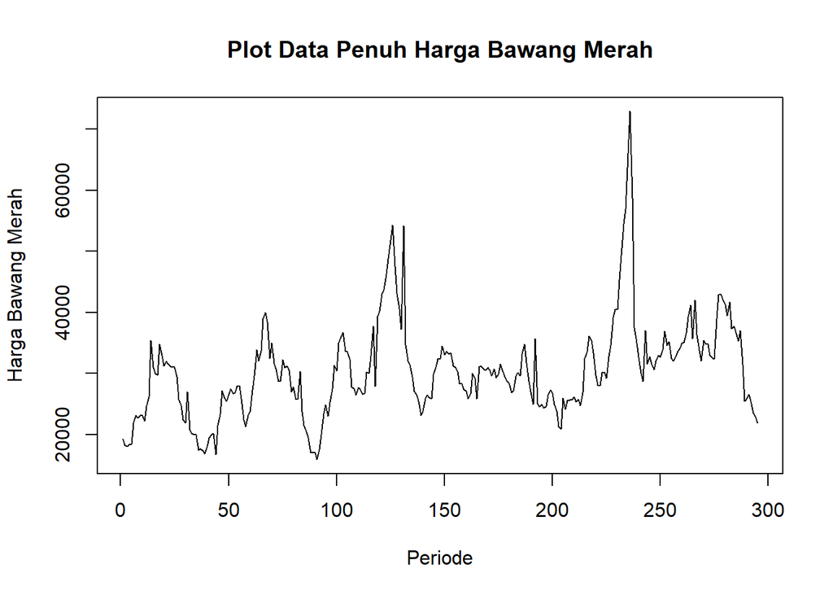

```r
data.ts <- ts(data$BawangMerah)
plot.ts(data.ts, lty=1, xlab="Periode", ylab="Harga Bawang Merah", main="Plot Data Penuh Harga Bawang Merah")
```

Plot deret waktu di atas menunjukkan bahwa data stasioner dalam rataan, ditandai dengan data cenderung menyebar di sekitar nilai tengahnya

### Data Latih

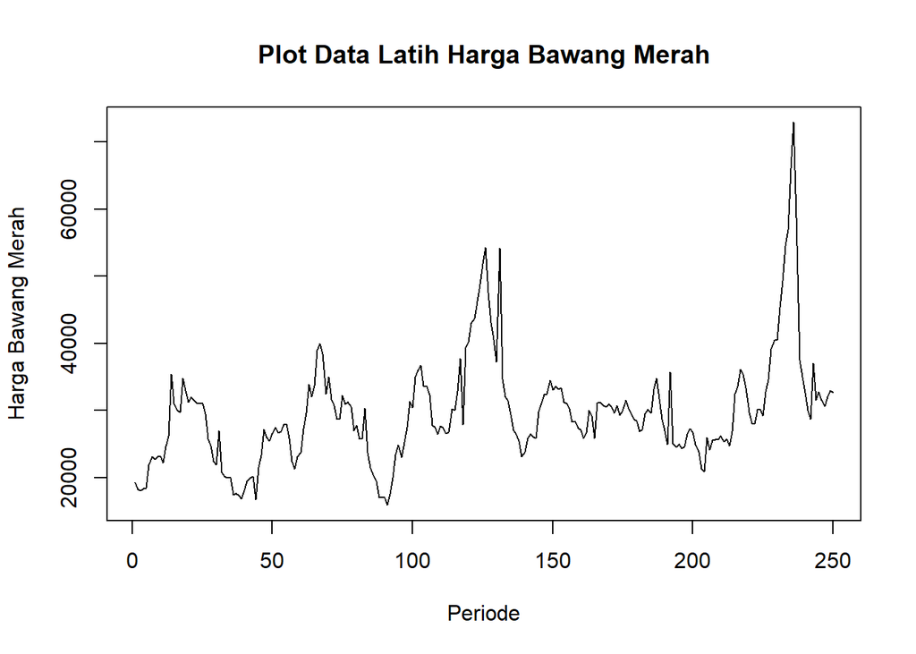

```r
train<-data$BawangMerah[1:250]
train.ts<-ts(train)
plot.ts(train.ts, lty=1, xlab="Periode", ylab="Harga Bawang Merah", main="Plot Data Latih Harga Bawang Merah")
```

Berdasarkan plot data deret waktu pada data latih, terlihat bahwa data stasioner dalam rataan, ditandai dengan data cenderung menyebar di sekitar nilai tengahnya

### Data Uji

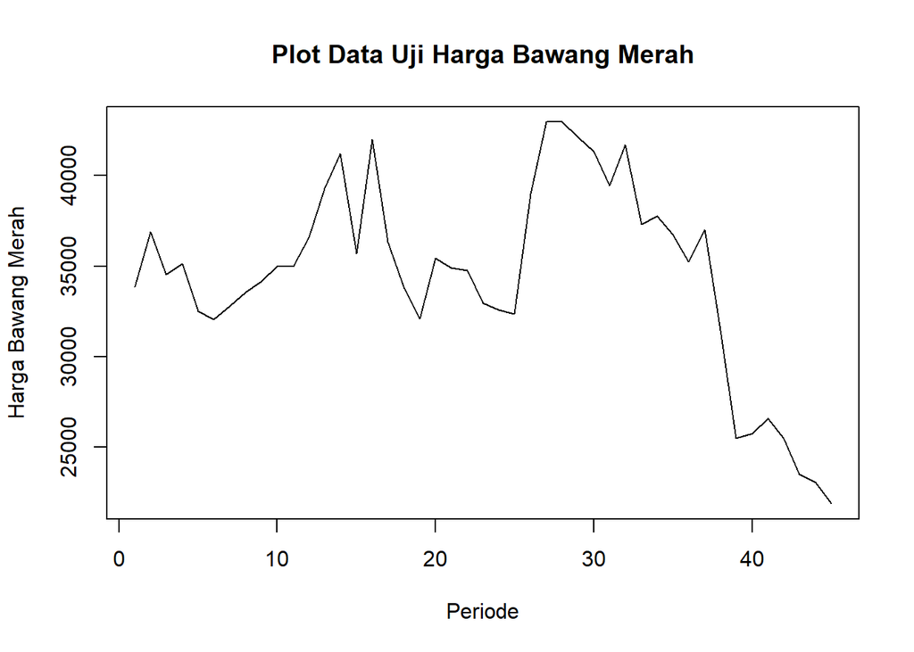

```r
test<-data$BawangMerah[-c(1:250)]
test.ts<-ts(test)
plot.ts(test.ts, lty=1, xlab="Periode", ylab="Harga Bawang Merah", main="Plot Data Uji Harga Bawang Merah")
```

## Plot ACF

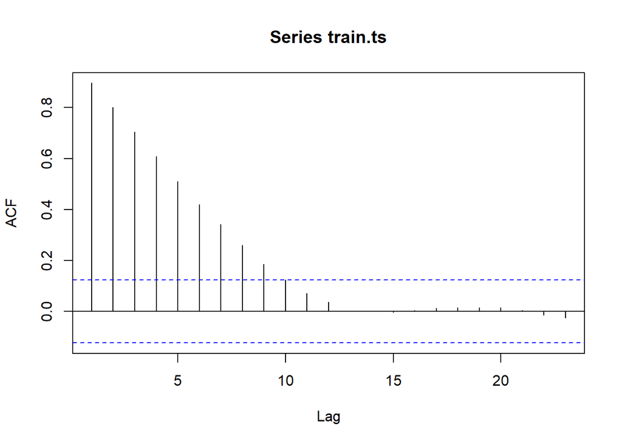

```r
acf(train.ts)
```

Berdasarkan plot ACF, terlihat bahwa plot ACF pada data tersebut *tails off slowly* atau menurun secara perlahan.

## Uji ADF

```r
tseries::adf.test(train.ts)
```

```
##
##  Augmented Dickey-Fuller Test
##
## data:  train.ts
## Dickey-Fuller = -4.1727, Lag order = 6, p-value = 0.01
## alternative hypothesis: stationary
```

$H_0$ : Data tidak stasioner dalam rataan

$H_1$ : Data stasioner dalam rataan

Berdasarkan uji ADF tersebut, didapat *p-value* sebesar 0.01 yang lebih kecil dari taraf nyata 5% sehingga tolak $H_0$ dan menandakan bahwa data stasioner dalam rataan.

## Plot Box-Cox

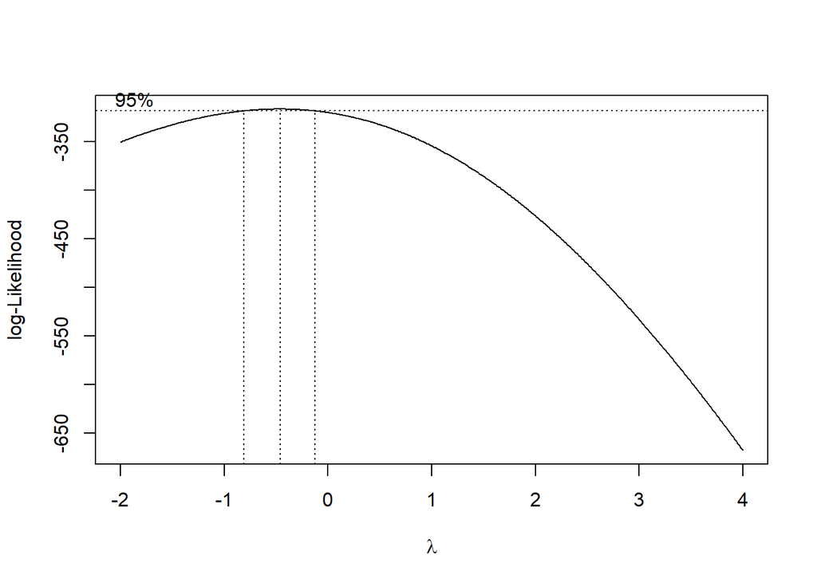

```r
index <- seq(1:250)
bc = boxcox(train.ts~index, lambda = seq(-2,4,by=0.01))
```

```r
#Nilai Rounded Lambda
lambda <- bc$x[which.max(bc$y)]
lambda
```

```
## [1] -0.46
```

```r
#SK
bc$x[bc$y > max(bc$y) - 1/2 * qchisq(.95,1)]
```

```
##  [1] -0.81 -0.80 -0.79 -0.78 -0.77 -0.76 -0.75 -0.74 -0.73 -0.72 -0.71 -0.70
## [13] -0.69 -0.68 -0.67 -0.66 -0.65 -0.64 -0.63 -0.62 -0.61 -0.60 -0.59 -0.58
## [25] -0.57 -0.56 -0.55 -0.54 -0.53 -0.52 -0.51 -0.50 -0.49 -0.48 -0.47 -0.46
## [37] -0.45 -0.44 -0.43 -0.42 -0.41 -0.40 -0.39 -0.38 -0.37 -0.36 -0.35 -0.34
## [49] -0.33 -0.32 -0.31 -0.30 -0.29 -0.28 -0.27 -0.26 -0.25 -0.24 -0.23 -0.22
## [61] -0.21 -0.20 -0.19 -0.18 -0.17 -0.16 -0.15 -0.14 -0.13
```

Dengan demikian, data stasioner dalam rataan tetapi tidak stasioner dalam ragam.

# Identifikasi Model

## Plot ACF

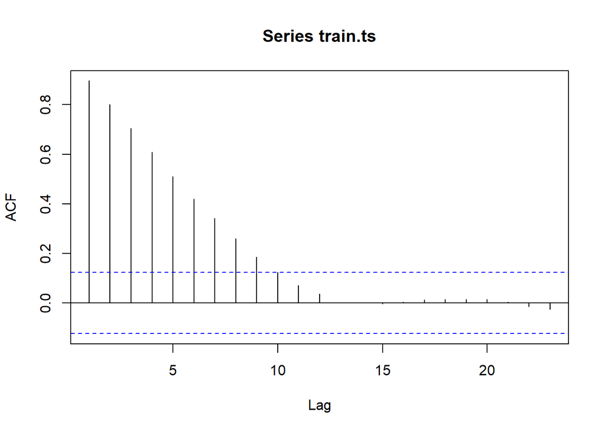

```r
acf(train.ts)
```

Berdasarkan plot tersebut, terlihat bahwa plot ACF *tails off*.

## Plot PACF

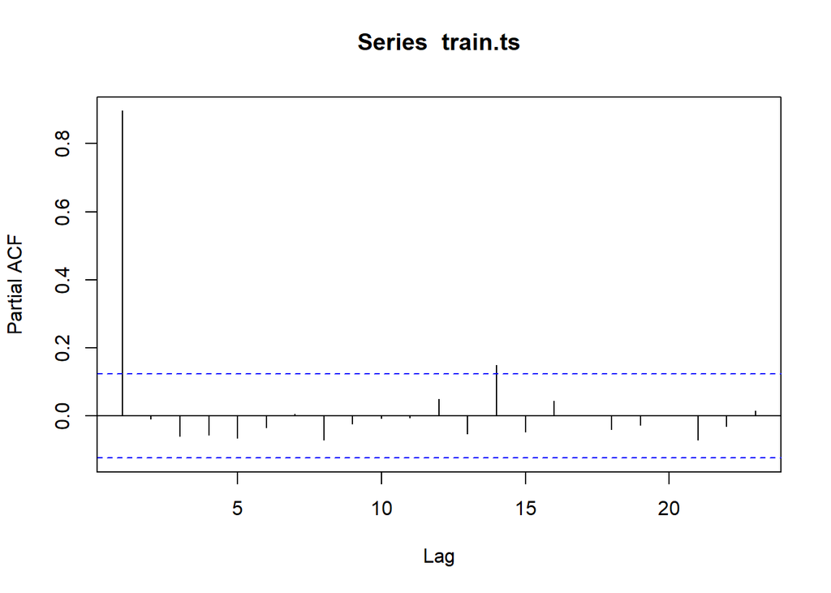

```r
pacf(train.ts)
```

Berdasarkan plot tersebut, terlihat bahwa plot PACF cenderung *cuts off* pada lag ke 1 dan plot ACF menunjukkan *tails off*, maka model tentatifnya adalah ARIMA(1,0,0) atau AR(1).

## Plot EACF

```r
eacf(train.ts)
```

```
## AR/MA
##   0 1 2 3 4 5 6 7 8 9 10 11 12 13
## 0 x x x x x x x x x o o  o  o  o
## 1 o o o o o o o o o o o  o  o  o
## 2 o o o o o o o o o o o  o  o  o
## 3 x o o o o o o o o o o  o  o  o
## 4 x x x o o o o o o o o  o  o  o
## 5 x x x o o o o o o o o  o  o  o
## 6 o x x x o o o o o o o  o  o  o
## 7 o x x x o x o o o o o  o  o  o
```

Identifikasi model menggunakan plot EACF dilakukan dengan melihat ujung segitiga pada pola segitiga nol. Dalam hal ini model tentatif yang terbentuk adalah ARIMA(1,0,0) dan ARIMA (2,0,0)

# Pendugaan Parameter Model Tentatif

## ARIMA(1,0,0)

```r
model1=Arima(train.ts, order=c(1,0,0),method="ML")
summary(model1) #AIC=4803.98
```

```
## Series: train.ts
## ARIMA(1,0,0) with non-zero mean
##
## Coefficients:
##          ar1       mean
##       0.8991  29446.480
## s.e.  0.0272   2148.626
##
## sigma^2 = 12679296:  log likelihood = -2398.99
## AIC=4803.98   AICc=4804.08   BIC=4814.55
##
## Training set error measures:
##                    ME     RMSE      MAE        MPE     MAPE     MASE
## Training set 59.27675 3546.528 2260.691 -0.9430064 7.326402 1.015445
##                     ACF1
## Training set 0.002600081
```

```r
lmtest::coeftest(model1) #seluruh parameter signifikan
```

```
##
## z test of coefficients:
##
##             Estimate Std. Error z value  Pr(>|z|)
## ar1       8.9909e-01 2.7167e-02  33.095 < 2.2e-16 ***
## intercept 2.9446e+04 2.1486e+03  13.705 < 2.2e-16 ***
## ---
## Signif. codes:  0 '***' 0.001 '**' 0.01 '*' 0.05 '.' 0.1 ' ' 1
```

## ARIMA(2,0,0)

```r
model2=Arima(train.ts, order=c(2,0,0),method="ML")
summary(model2) #AIC=1492.73
```

```
## Series: train.ts
## ARIMA(2,0,0) with non-zero mean
##
## Coefficients:
##          ar1      ar2       mean
##       0.9025  -0.0037  29445.698
## s.e.  0.0630   0.0633   2144.243
##
## sigma^2 = 12730399:  log likelihood = -2398.99
## AIC=4805.98   AICc=4806.14   BIC=4820.07
##
## Training set error measures:
##                    ME     RMSE      MAE        MPE     MAPE     MASE
## Training set 59.24011 3546.496 2258.657 -0.9428676 7.320043 1.014531
##                      ACF1
## Training set -0.001007811
```

```r
lmtest::coeftest(model2) #ar2 tidak signifikan
```

```
##
## z test of coefficients:
##
##              Estimate  Std. Error z value Pr(>|z|)
## ar1        9.0250e-01  6.3015e-02 14.3220   <2e-16 ***
## ar2       -3.6515e-03  6.3264e-02 -0.0577    0.954
## intercept  2.9446e+04  2.1442e+03 13.7324   <2e-16 ***
## ---
## Signif. codes:  0 '***' 0.001 '**' 0.01 '*' 0.05 '.' 0.1 ' ' 1
```

# Diagnostik Model

## Eksplorasi

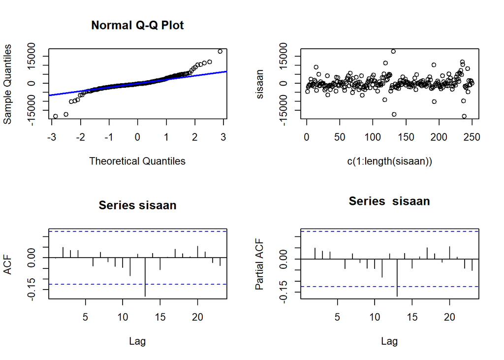

```r
#Eksplorasi
sisaan<- model2$residuals
par(mfrow=c(2,2))
qqnorm(sisaan)
qqline(sisaan, col = "blue", lwd = 2)
plot(c(1:length(sisaan)),sisaan)
acf(sisaan)
pacf(sisaan)
```

```r
par(mfrow = c(1,1))
```